# Intro to R for Chipseeker

## RStudio

1. When you open RStudio, open your project in the data folder you downloaded in preparation for this class. You should see your bed files in the file tab of your RStudio instance.
- It is useful to initiate your organize your data, data preprocessing scripts, data visualizations, etc., per project.
2. Four quadrants of RStudio
- Upper left: .R files / script input
- Lower left: Console / script output
- Upper right: Global environment
- Lower right: Files, Plots, Packages, Help, Viewer

## Creating variables in R

Variables allow you to store information within keywords. This stored information can be a single data element, like a string, a number, or a boolean, or variables can be used to store more complicated data structures such as lists, dataframes, graphs, and custom user-created functions.

Variables in R are created using the following notation: <-

#### Single datum and lists stored as variables

`r x <- 1 x`

`## [1] 1`

`r y <- "single string" y`

`## [1] "single string"`

```r
numerical_list = c(0.75, 10, 8, 7, 5, 6.5)
numerical_list
```

```
## [1]  0.75 10.00  8.00  7.00  5.00  6.50
```

```r
list_of_strings <- c("Elo", "Charlie", "Molly", "Woody", "Monte", "Ben")
list_of_strings
```

```
## [1] "Elo"     "Charlie" "Molly"   "Woody"   "Monte"   "Ben"
```

#### Data structures stored as variables

Load a sample dataset from the CRAN (VADeaths).

```r
data("VADeaths")
```

View a summary of this dataframe

```r
summary(VADeaths)
```

```
##    Rural Male     Rural Female     Urban Male     Urban Female
##  Min.   :11.70   Min.   : 8.70   Min.   :15.40   Min.   : 8.40
##  1st Qu.:18.10   1st Qu.:11.70   1st Qu.:24.30   1st Qu.:13.60
##  Median :26.90   Median :20.30   Median :37.00   Median :19.30
##  Mean   :32.74   Mean   :25.18   Mean   :40.48   Mean   :25.28
##  3rd Qu.:41.00   3rd Qu.:30.90   3rd Qu.:54.60   3rd Qu.:35.10
##  Max.   :66.00   Max.   :54.30   Max.   :71.10   Max.   :50.00
```

View a preview of this dataset using the head() function.

```r
head(VADeaths)
```

```
##       Rural Male Rural Female Urban Male Urban Female
## 50-54       11.7          8.7       15.4          8.4
## 55-59       18.1         11.7       24.3         13.6
## 60-64       26.9         20.3       37.0         19.3
## 65-69       41.0         30.9       54.6         35.1
## 70-74       66.0         54.3       71.1         50.0
```

View a subset of this data. How would we include only ages 50 to 64 for Urban Females?

`r VAsubsetUF <- VADeaths[1:3, "Urban Female"] VAsubsetUF`

`## 50-54 55-59 60-64 ## 8.4 13.6 19.3`

## Using functions in R

Functions allow you to perform complicated tasks in R without custom codeing every detail. Functions are either part of Base R, or they are tied to a particular package. Base R includes mathmatical, basic stats and basic graphs. Packages add additional functions that may allow for more customization or more specific analysis types.

Functions take arguments and provide results.

#### Plotting functions in Base R

Using the subset data from our VA example, this function will make a barplot.

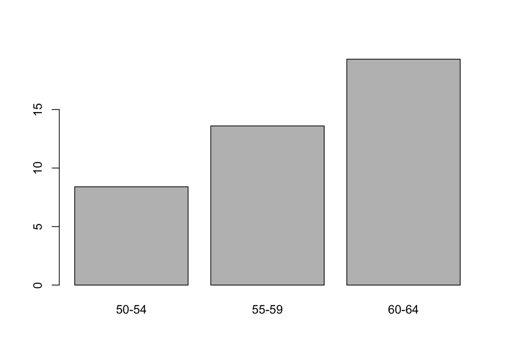

```r
barplot(VAsubsetUF)
```

Even with plots in base R, you have the ability to customize graphs.

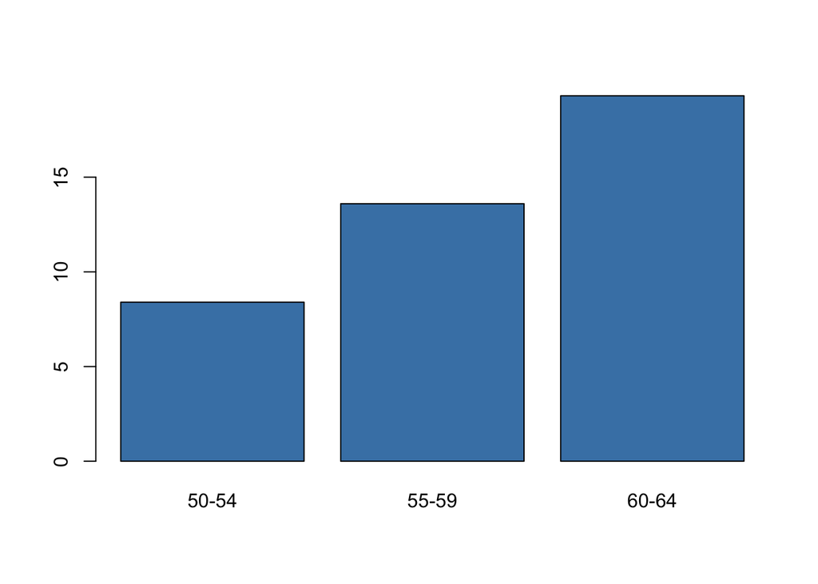

```r
barplot(VAsubsetUF, col = "steelblue")
```

If you have the ability to feed more than one option into a single argument, you will provide that argument with a list.

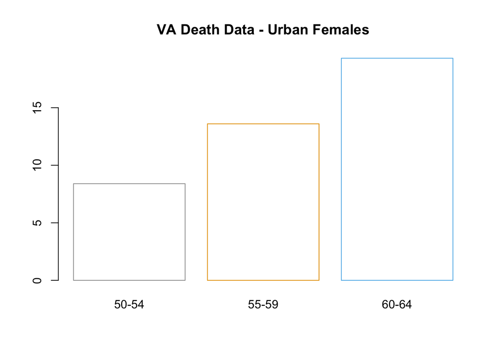

```r
barplot(VAsubsetUF, col = "white",
        border = c("#999999", "#E69F00", "#56B4E9"),
        main = "VA Death Data - Urban Females")
```

#### Referencing documentation about functions

The help() fucntion and the ? help operator in R provide access to R documentation.

Referencing documentation for the averaging function, specifying that you would like the mean function from base R (opposed to another package which might also have a mean function):

`r mean(35, 64, 85)`

`## [1] 35`

```r
?base::mean
```

Since you use functions to create graphs, these you can also reference in the documentation. This will provide you with a full list of arguments and customizable features, as well as some examples of how the function might be used or configured.

```r
?barplot
```